### Логистическая регрессия

Набор данных доноров содержит 93 462 примера людей, отправленных по почте в ходе сбора средств для парализованных военных ветеранов. Столбец пожертвований равен 1, если человек сделал пожертвование в ответ на рассылку, и 0 в противном случае. Этот двоичный результат будет зависимой переменной для модели логистической регрессии.

Остальные столбцы - это характеристики потенциальных доноров, которые могут влиять на их поведение в отношении пожертвований. Это независимые переменные модели.

При построении регрессионной модели часто полезно сформировать гипотезу о том, какие независимые переменные будут предиктивными для зависимой переменной. Столбец bad_address, для которого недопустимый почтовый адрес равен 1, в противном случае - 0, похоже, что он может уменьшить вероятность пожертвования. Точно так же можно подозревать, что религиозный интерес (Interest_religion) и интерес к делам ветеранов (Interest_veterans) будут связаны с большей благотворительностью.

```r
library(readr)
donors <- read_csv('donors.csv')
```

Смотрим как выглядит табличка и смотрим на баланс классов.

```r
str(donors)
```

```
## Classes 'spec_tbl_df', 'tbl_df', 'tbl' and 'data.frame': 93462 obs. of  13 variables:
##  $ donated          : num  0 0 0 0 0 0 0 0 0 0 ...
##  $ veteran          : num  0 0 0 0 0 0 0 0 0 0 ...
##  $ bad_address      : num  0 0 0 0 0 0 0 0 0 0 ...
##  $ age              : num  60 46 NA 70 78 NA 38 NA NA 65 ...
##  $ has_children     : num  0 1 0 0 1 0 1 0 0 0 ...
##  $ wealth_rating    : num  0 3 1 2 1 0 2 3 1 0 ...
##  $ interest_veterans: num  0 0 0 0 0 0 0 0 0 0 ...
##  $ interest_religion: num  0 0 0 0 1 0 0 0 0 0 ...
##  $ pet_owner        : num  0 0 0 0 0 0 1 0 0 0 ...
##  $ catalog_shopper  : num  0 0 0 0 1 0 0 0 0 0 ...
##  $ recency          : chr  "CURRENT" "CURRENT" "CURRENT" "CURRENT" ...
##  $ frequency        : chr  "FREQUENT" "FREQUENT" "FREQUENT" "FREQUENT" ...
##  $ money            : chr  "MEDIUM" "HIGH" "MEDIUM" "MEDIUM" ...
##  - attr(*, "spec")=
##   .. cols(
##   ..   donated = col_double(),
##   ..   veteran = col_double(),
##   ..   bad_address = col_double(),
##   ..   age = col_double(),
##   ..   has_children = col_double(),
##   ..   wealth_rating = col_double(),
##   ..   interest_veterans = col_double(),
##   ..   interest_religion = col_double(),
##   ..   pet_owner = col_double(),
##   ..   catalog_shopper = col_double(),
##   ..   recency = col_character(),
##   ..   frequency = col_character(),
##   ..   money = col_character()
##   .. )
```

```r
table(donors$donated)
```

```
##
##     0     1
## 88751  4711
```

```r
donation_model <- glm(formula = donated ~ bad_address + interest_religion +
                                          interest_veterans,
                      data = donors, family = "binomial")
summary(donation_model)
```

```
##
## Call:
## glm(formula = donated ~ bad_address + interest_religion + interest_veterans,
##     family = "binomial", data = donors)
##
## Deviance Residuals:
##     Min       1Q   Median       3Q      Max
## -0.3480  -0.3192  -0.3192  -0.3192   2.5678
##
## Coefficients:
##                   Estimate Std. Error  z value Pr(>|z|)
## (Intercept)       -2.95139    0.01652 -178.664   <2e-16 ***
## bad_address       -0.30780    0.14348   -2.145   0.0319 *
## interest_religion  0.06724    0.05069    1.327   0.1847
## interest_veterans  0.11009    0.04676    2.354   0.0186 *
## ---
## Signif. codes:  0 '***' 0.001 '**' 0.01 '*' 0.05 '.' 0.1 ' ' 1
##
## (Dispersion parameter for binomial family taken to be 1)
##
##     Null deviance: 37330  on 93461  degrees of freedom
## Residual deviance: 37316  on 93458  degrees of freedom
## AIC: 37324
##
## Number of Fisher Scoring iterations: 5
```

Сделаем прогноз в виде с помощью функции `predict`, параметр `type = "response"` означает, что мы хотим получить прогноз в виде вероятности.

```r
donors$donation_prob <- predict(donation_model, type = "response")
```

Теперь выбрав порог поставим метки 1 или 0. И посчитаем `accuracy`.

```r
donors$donation_pred <- ifelse(donors$donation_prob > 0.0504, 1, 0)
mean(donors$donation_pred == donors$donated)
```

```
## [1] 0.794815
```

Получилось около 80%. Говорит ли нам это о том, что алгоритм хорошо работает? Давайте попробуем найти какой был бы accuracy, если бы у нас был алгоритм, который выдавал только 0.

```r
mean(donors$donated == 0)
```

```
## [1] 0.9495945
```

0.95! То есть наш алогритм работает хуже, чем константный алгоритм.

### ROC-AUC

Подгружаем пакет, вычисляем ROC-кривую, рисуем ее и считаем AUC.

```r
# Load the pROC package
library('pROC')
```

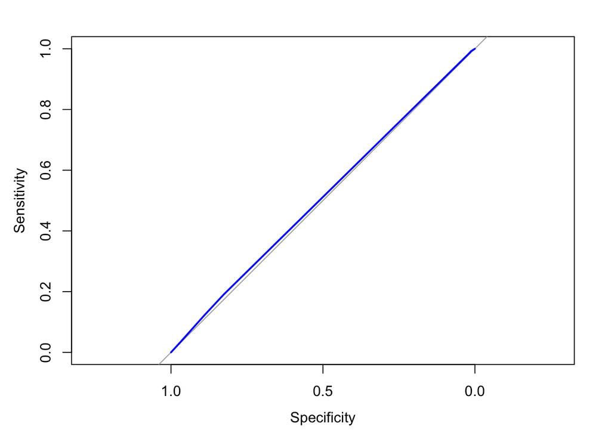

```r
# Create a ROC curve
ROC <- roc(donors$donated, donors$donation_prob)
# Plot the ROC curve
plot(ROC, col = 'blue')
```

```r
# Calculate the area under the curve (AUC)
auc(ROC)
```

```
## Area under the curve: 0.5102
```

Теперь видим, что модель не лучше чем обычный алгоритм.

AUC не всегда означает, что одна модель лучше другой. Для разных задач все может быть по-разному.

### Дамми переменные, пропущенные значения и эффект.

#### Дамми переменные

Все переменные должны быть числовыми. То есть все категориальные переменные нужно представить в виде цифр. Пропущенные значения тоже мешают, так как мы не можем вычислить прогноз.

glm автоматически переводит категориальные переменные в числовые(Лучше показать OHE)

```r
# Convert the wealth rating to a factor
donors$wealth_rating <- factor(donors$wealth_rating, levels = 0:3,
                                labels = c('Unknown', 'Low', 'Medium', 'High'))

# Use relevel() to change reference category
donors$wealth_rating <- relevel(donors$wealth_rating, ref = 'Medium')

# See how our factor coding impacts the model
summary(glm(donated~wealth_rating, data = donors,
            family = "binomial"))
```

```
##
## Call:
## glm(formula = donated ~ wealth_rating, family = "binomial", data = donors)
##
## Deviance Residuals:
##     Min       1Q   Median       3Q      Max
## -0.3320  -0.3243  -0.3175  -0.3175   2.4582
##
## Coefficients:
##                      Estimate Std. Error z value Pr(>|z|)
## (Intercept)          -2.91894    0.03614 -80.772   <2e-16 ***
## wealth_ratingUnknown -0.04373    0.04243  -1.031    0.303
## wealth_ratingLow     -0.05245    0.05332  -0.984    0.325
## wealth_ratingHigh     0.04804    0.04768   1.008    0.314
## ---
## Signif. codes:  0 '***' 0.001 '**' 0.01 '*' 0.05 '.' 0.1 ' ' 1
##
## (Dispersion parameter for binomial family taken to be 1)
##
##     Null deviance: 37330  on 93461  degrees of freedom
## Residual deviance: 37323  on 93458  degrees of freedom
## AIC: 37331
##
## Number of Fisher Scoring iterations: 5
```

releval сделал medium более важной

#### пропущенные значения

пропущенные данные можно заполнить средним значением по этой переменной и создать еще одну переменную, в которой мы укажем, что это значение отсутствовало и мы его заменили средним

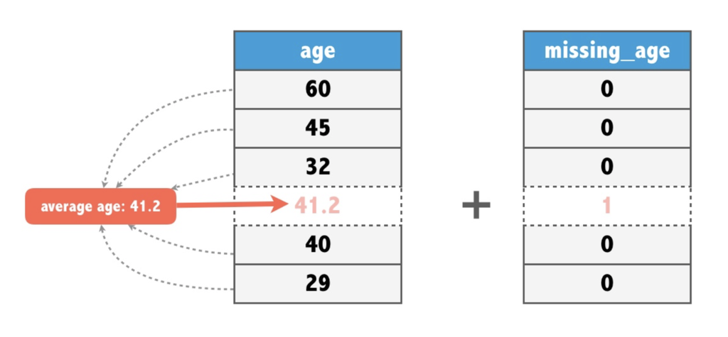

```r
# Find the average age among non-missing values
summary(donors$age)
```

```
##    Min. 1st Qu.  Median    Mean 3rd Qu.    Max.    NA's
##    1.00   48.00   62.00   61.65   75.00   98.00   22546
```

```r
# Impute missing age values with the mean age
donors$imputed_age <- ifelse(is.na(donors$age), round(mean(donors$age, na.rm=TRUE),2), donors$age)

# Create missing value indicator for age
donors$missing_age <- ifelse(is.na(donors$age),1,0)
```

#### Эффект

Иногда взаимодействие переменных может дать резльут лучше чем отдельные переменные или наоборот ничего не дать.

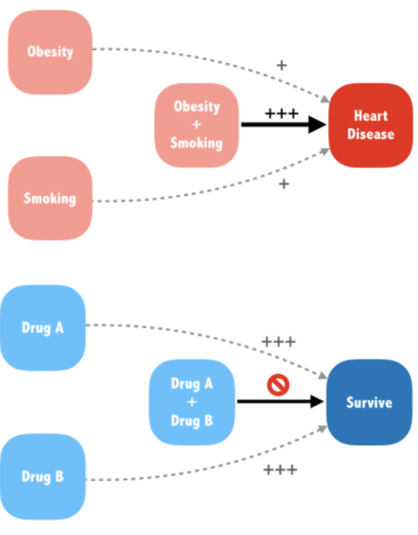

Сделаем модель с эффектом

```r
# Build a recency, frequency, and money (RFM) model
rfm_model <- glm(formula = donated ~ money + recency*frequency,
                  data = donors,
                  family='binomial')

# Summarize the RFM model to see how the parameters were coded
summary(rfm_model)
```

```
##
## Call:
## glm(formula = donated ~ money + recency * frequency, family = "binomial",
##     data = donors)
##
## Deviance Residuals:
##     Min       1Q   Median       3Q      Max
## -0.3696  -0.3696  -0.2895  -0.2895   2.7924
##
## Coefficients:
##                                   Estimate Std. Error z value Pr(>|z|)
## (Intercept)                       -3.01142    0.04279 -70.375   <2e-16 ***
## moneyMEDIUM                        0.36186    0.04300   8.415   <2e-16 ***
## recencyLAPSED                     -0.86677    0.41434  -2.092   0.0364 *
## frequencyINFREQUENT               -0.50148    0.03107 -16.143   <2e-16 ***
## recencyLAPSED:frequencyINFREQUENT  1.01787    0.51713   1.968   0.0490 *
## ---
## Signif. codes:  0 '***' 0.001 '**' 0.01 '*' 0.05 '.' 0.1 ' ' 1
##
## (Dispersion parameter for binomial family taken to be 1)
##
##     Null deviance: 37330  on 93461  degrees of freedom
## Residual deviance: 36938  on 93457  degrees of freedom
## AIC: 36948
##
## Number of Fisher Scoring iterations: 6
```

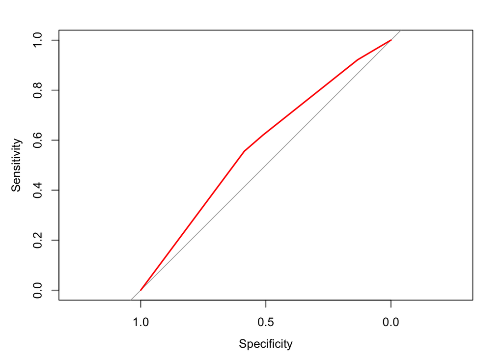

```r
# Compute predicted probabilities for the RFM model
rfm_prob <- predict(rfm_model, type = "response")

# Plot the ROC curve and find AUC for the new model
library(pROC)
ROC <- roc(donors$donated, rfm_prob)
plot(ROC, col = "red")
```

```r
auc(ROC)
```

```
## Area under the curve: 0.5785
```

### Автоматический отбор признаков

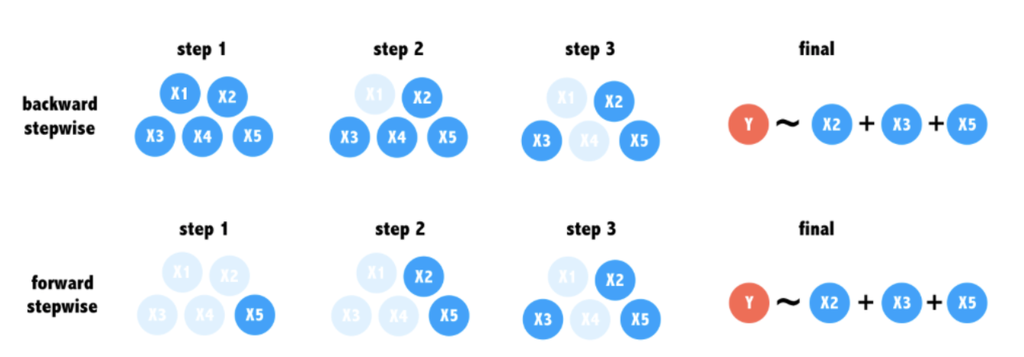

Вот такие методы есть

они не всегда дают одинаковые результаты

Опасности ступенчатой регрессии Несмотря на свою полезность для выбора признаков, ступенчатая регрессия не часто используется в дисциплинах вне машинного обучения из-за некоторых важных предостережений. Что из этого НЕ является одной из этих проблем?

1 Не гарантируется найти лучшую модель

2 Прогнозам ступенчатой модели нельзя доверять

3 Процедура ступенчатой регрессии нарушает некоторые статистические допущения

4 Это может привести к модели, которая имеет мало смысла в реальном мире

Ответ:2 Верный! Хотя ступенчатая регрессия осуждается, она все же может быть полезна для построения прогностических моделей при отсутствии другого стартового места.

Попробуем добавлять предикторы по одному

Примените step () к этим моделям, чтобы выполнить пошаговую регрессию вперед. Установите для первого аргумента значение null_model и установите direction = “forward”. Это может занять некоторое время (до 10 или 15 секунд), так как ваш компьютер должен соответствовать нескольким различным моделям для выполнения пошагового выбора.

```r
# Specify a null model with no predictors
null_model <- glm(donated ~ 1, data = donors, family = "binomial")

# Specify the full model using all of the potential predictors
full_model <- glm(donated ~ ., data = donors, family = "binomial")

# Use a forward stepwise algorithm to build a parsimonious model
step_model <- step(null_model, scope = list(lower = null_model, upper = full_model), direction = "forward")
```

```
## Start:  AIC=37332.13
## donated ~ 1
```

```
##                     Df Deviance   AIC
## + frequency          1    28502 37122
## + money              1    28621 37241
## + has_children       1    28705 37326
## + age                1    28707 37328
## + imputed_age        1    28707 37328
## + wealth_rating      3    28704 37328
## + interest_veterans  1    28709 37330
## + donation_prob      1    28710 37330
## + donation_pred      1    28710 37330
## + catalog_shopper    1    28710 37330
## + pet_owner          1    28711 37331
## <none>                    28714 37332
## + interest_religion  1    28712 37333
## + recency            1    28713 37333
## + bad_address        1    28714 37334
## + veteran            1    28714 37334
##
## Step:  AIC=37024.77
## donated ~ frequency
```

```
##                     Df Deviance   AIC
## + money              1    28441 36966
## + wealth_rating      3    28490 37019
## + has_children       1    28494 37019
## + donation_prob      1    28498 37023
## + interest_veterans  1    28498 37023
## + catalog_shopper    1    28499 37024
## + donation_pred      1    28499 37024
## + age                1    28499 37024
## + imputed_age        1    28499 37024
## + pet_owner          1    28499 37024
## <none>                    28502 37025
## + interest_religion  1    28501 37026
## + recency            1    28501 37026
## + bad_address        1    28502 37026
## + veteran            1    28502 37027
##
## Step:  AIC=36949.71
## donated ~ frequency + money
```

```
##                     Df Deviance   AIC
## + wealth_rating      3    28427 36942
## + has_children       1    28432 36943
## + interest_veterans  1    28438 36948
## + donation_prob      1    28438 36949
## + catalog_shopper    1    28438 36949
## + donation_pred      1    28438 36949
## + age                1    28438 36949
## + imputed_age        1    28438 36949
## + pet_owner          1    28439 36949
## <none>                    28441 36950
## + interest_religion  1    28440 36951
## + recency            1    28440 36951
## + bad_address        1    28441 36951
## + veteran            1    28441 36952
##
## Step:  AIC=36945.48
## donated ~ frequency + money + wealth_rating
```

```
##                     Df Deviance   AIC
## + has_children       1    28416 36937
## + age                1    28424 36944
## + imputed_age        1    28424 36944
## + interest_veterans  1    28424 36945
## + donation_prob      1    28424 36945
## + catalog_shopper    1    28424 36945
## + donation_pred      1    28425 36945
## <none>                    28427 36945
## + pet_owner          1    28425 36946
## + interest_religion  1    28426 36947
## + recency            1    28426 36947
## + bad_address        1    28427 36947
## + veteran            1    28427 36947
##
## Step:  AIC=36938.4
## donated ~ frequency + money + wealth_rating + has_children
```

```
##                     Df Deviance   AIC
## + pet_owner          1    28413 36937
## + donation_prob      1    28413 36937
## + catalog_shopper    1    28413 36937
## + interest_veterans  1    28413 36937
## + donation_pred      1    28414 36938
## <none>                    28416 36938
## + interest_religion  1    28415 36939
## + age                1    28416 36940
## + imputed_age        1    28416 36940
## + recency            1    28416 36940
## + bad_address        1    28416 36940
## + veteran            1    28416 36940
##
## Step:  AIC=36932.25
## donated ~ frequency + money + wealth_rating + has_children +
##     pet_owner
```

```
##                     Df Deviance   AIC
## <none>                    28413 36932
## + donation_prob      1    28411 36932
## + interest_veterans  1    28411 36932
## + catalog_shopper    1    28412 36933
## + donation_pred      1    28412 36933
## + age                1    28412 36933
## + imputed_age        1    28412 36933
## + recency            1    28413 36934
## + interest_religion  1    28413 36934
## + bad_address        1    28413 36934
## + veteran            1    28413 36934
```

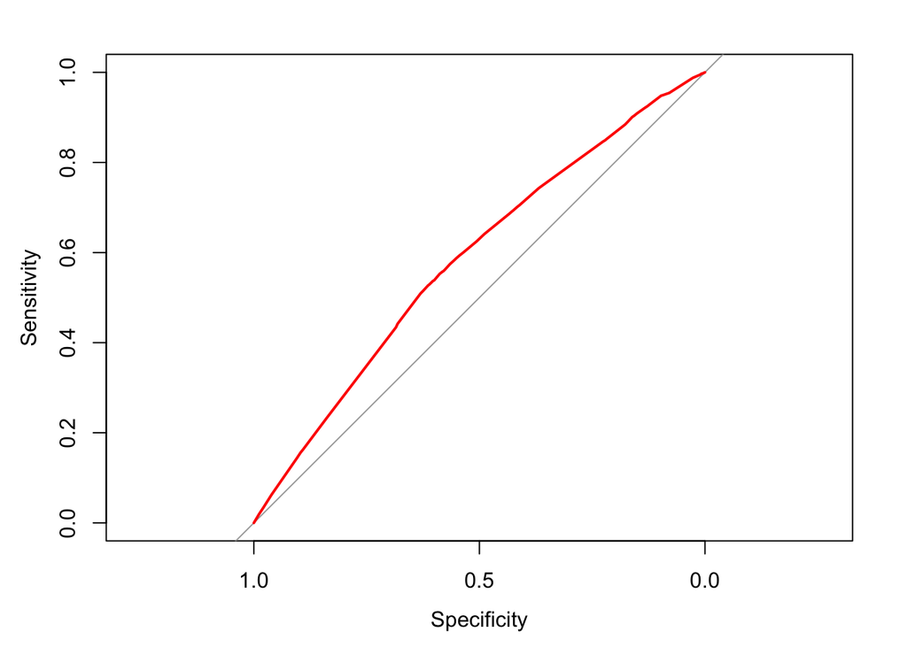

```r
# Estimate the stepwise donation probability
step_prob <- predict(step_model, type = 'response')

# Plot the ROC of the stepwise model
library(pROC)
ROC <- roc(donors$donated, step_prob)
plot(ROC, col = "red")
```

```r
auc(ROC)
```

```
## Area under the curve: 0.5849
```